# Reproducing the manuscript numbers, tables, and figures

Companion to *Three Routes to One Answer: Reconciling AIPW, TMLE, and Double Machine Learning for Applied Researchers*

The figures and data-bearing tables of the manuscript prepared for arXiv version 2 ([arXiv:2609.26142](https://arxiv.org/abs/2609.26142); v2 forthcoming) are regenerated below **directly from the committed result CSVs**, and a numeric audit checks the reported numbers against them; the Super Learner engine is **not** re-run here. Each figure is the PDF drawn by [`R/make_figures.R`](https://github.com/ehsanx/dml-alternatives/blob/main/R/make_figures.R) (the R scripts in [`R/figures/`](https://github.com/ehsanx/dml-alternatives/tree/main/R/figures) and [`python/paper_figures.py`](https://github.com/ehsanx/dml-alternatives/blob/main/python/paper_figures.py)), shown as a 200-dpi image; the three schematics (Figures 1, 3 and 4) use no data. The estimator code lives in [`R/`](https://github.com/ehsanx/dml-alternatives/tree/main/R); the results it produced are frozen in [`docs/data/`](https://github.com/ehsanx/dml-alternatives/tree/main/docs/data). For the methods themselves, read the paper.

**Double cross-fitting corrected (October 2026)**

The double cross-fit (DC-AIPW, DC-TMLE) released with arXiv version 1 averaged the predictions of both role assignments, so the propensity and outcome models were not trained on disjoint folds. The engine now uses one fixed rotation (score fold *v* with *g* fit on fold *v*+1 and *Q* on fold *v*+2, mod 3), and every double-cross-fit result was rerun with the original fold seeds. The CSVs below carry the corrected rows; every other row is unchanged. The repository [`README`](https://github.com/ehsanx/dml-alternatives/blob/main/README.md#correction) lists the main corrected values.

To reproduce the CSVs from scratch instead (re-running the engine), see the scripts in [`R/`](https://github.com/ehsanx/dml-alternatives/tree/main/R), the repository [`README`](https://github.com/ehsanx/dml-alternatives/blob/main/README.md), and the data sources and computing environments at the end of this page.

```r
## Stage the frozen CSVs in output/, where R/ihdp_contrasts.R reads and writes, and read them from
## there. Nothing below fits a model or touches raw microdata. The figures are the PDFs that
## R/render_page.R drew before rendering (output/figures/), shown as 200-dpi images.
dir.create("output", showWarnings = FALSE)
invisible(file.copy(list.files("data", full.names = TRUE), "output", overwrite = TRUE))

rd  <- function(f) read.csv(file.path("output", f), check.names = FALSE, stringsAsFactors = FALSE)
kab <- function(x, ...) knitr::kable(x, ...)
fig <- function(name) knitr::include_graphics(file.path("..", "output", "figures", "png", paste0(name, ".png")))
## a numeric table as written by R/make_tables.R, without its title line (the heading gives it)
tab <- function(n) cat(readLines(file.path("..", "output", "tables", sprintf("table%02d.md", n)))[-(1:2)], sep = "\n")
```

# The ten figures and the manuscript’s copies

[`R/render_page.R`](https://github.com/ehsanx/dml-alternatives/blob/main/R/render_page.R) draws the ten figures, then compares each PDF with the manuscript’s copy in [`figures/reference/`](https://github.com/ehsanx/dml-alternatives/tree/main/figures/reference) ([`tools/compare_pdf.py`](https://github.com/ehsanx/dml-alternatives/blob/main/tools/compare_pdf.py)): page count and page boxes, the page structure (content streams byte for byte, and every font and graphics resource they name), and both files rendered at 144 dpi. A pass needs Arial and the package versions in `renv.lock` and `requirements.txt`; elsewhere, `--text-only` is a limited fallback that compares the words only.

```
IDENTICAL   concept_grid.pdf: 1 page(s), boxes, content and resources equal; rendered at 144 dpi: 0 pixels differ
IDENTICAL   fitting_schemes.pdf: 1 page(s), boxes, content and resources equal; rendered at 144 dpi: 0 pixels differ
IDENTICAL   ihdp_calibration.pdf: 1 page(s), boxes, content and resources equal; rendered at 144 dpi: 0 pixels differ
IDENTICAL   nhefs_dag.pdf: 1 page(s), boxes, content and resources equal; rendered at 144 dpi: 0 pixels differ
IDENTICAL   nhefs_forest.pdf: 1 page(s), boxes, content and resources equal; rendered at 144 dpi: 0 pixels differ
IDENTICAL   nhefs_overlap.pdf: 1 page(s), boxes, content and resources equal; rendered at 144 dpi: 0 pixels differ
IDENTICAL   overlap_estimates.pdf: 1 page(s), boxes, content and resources equal; rendered at 144 dpi: 0 pixels differ
IDENTICAL   rhc_forest.pdf: 1 page(s), boxes, content and resources equal; rendered at 144 dpi: 0 pixels differ
IDENTICAL   rhc_reps.pdf: 1 page(s), boxes, content and resources equal; rendered at 144 dpi: 0 pixels differ
IDENTICAL   software_seeds.pdf: 1 page(s), boxes, content and resources equal; rendered at 144 dpi: 0 pixels differ
10 of 10 identical
```

# Figure 1 — NHEFS causal DAG

The hypothesized confounding structure (`fig:dag`), drawn by [`R/figures/fig_dag.R`](https://github.com/ehsanx/dml-alternatives/blob/main/R/figures/fig_dag.R) (no data): the nine baseline covariates `X` are common causes of quitting smoking (`A`) and weight change (`Y`), and form the adjustment set.

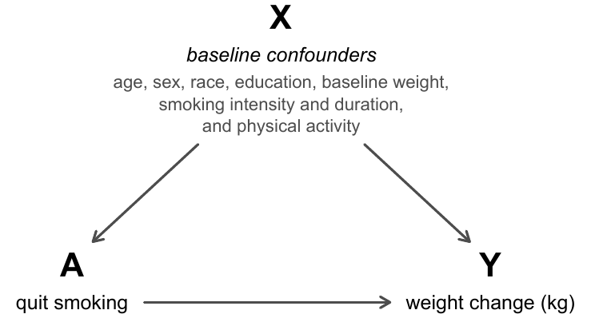

Figure 1

# Figure 2 — NHEFS propensity overlap

`fig:nhefs-overlap`, drawn by [`R/figures/fig_overlap.R`](https://github.com/ehsanx/dml-alternatives/blob/main/R/figures/fig_overlap.R) from `data/nhefs_overlap_data.csv`: the scores of the overlap diagnostic’s own fit. That fit was not seeded, so the file is the reference. The truncation audit of the analysis fits is below.

```
#> propensity range: [0.044, 0.759]
```

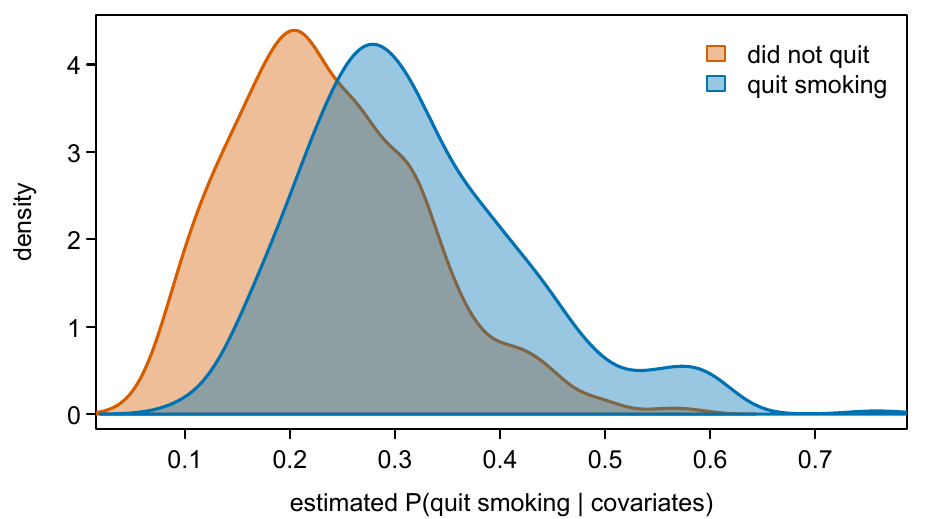

Figure 2

```r
fig("nhefs_overlap")
pp <- rd("nhefs_overlap_data.csv")
cat(sprintf("propensity range: [%.3f, %.3f]\n", min(pp$pi), max(pp$pi)))
```

# Figure 3 — One score, two choices, one target

`fig:concept`, drawn by [`python/paper_figures.py`](https://github.com/ehsanx/dml-alternatives/blob/main/python/paper_figures.py) (no data): one Super Learner supplies both nuisances, which assemble one efficient influence function; a combination rule (rows) and a fitting scheme (columns) give the six doubly-robust estimators of one target.

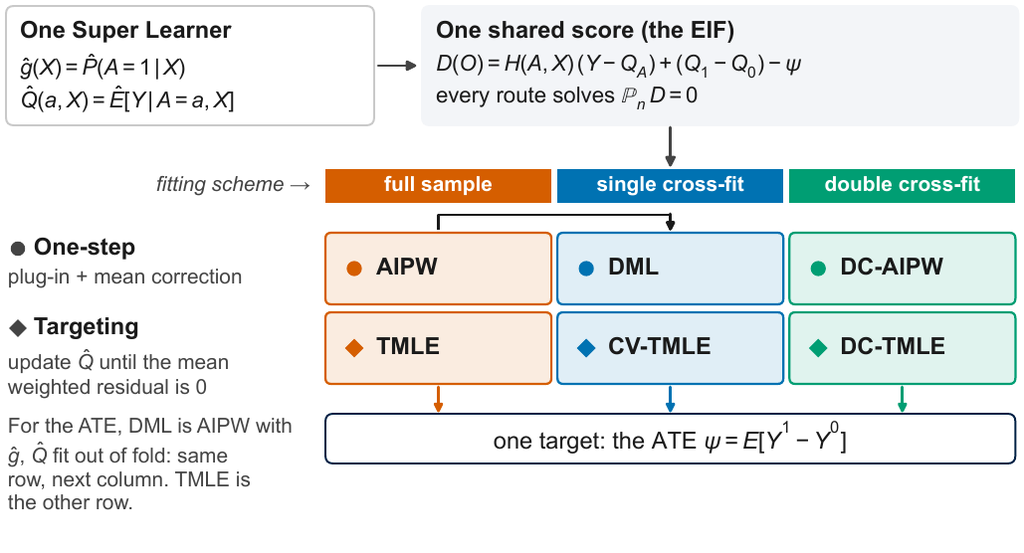

Figure 3

# Figure 4 — Fitting schemes

`fig:fitting-schemes`, drawn by [`python/paper_figures.py`](https://github.com/ehsanx/dml-alternatives/blob/main/python/paper_figures.py) (no data): which rows train the initial nuisance fits and which rows they predict, for the full-sample, single cross-fit (*V* = 5) and double cross-fit (*V* = 3) schemes.

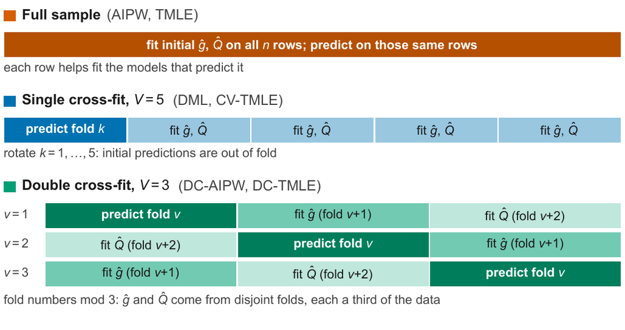

Figure 4

# Figure 5 — NHEFS estimator panel

`fig:nhefs-panel`, drawn by [`R/figures/fig_forests.R`](https://github.com/ehsanx/dml-alternatives/blob/main/R/figures/fig_forests.R) from `data/nhefs_panel_table.csv`.

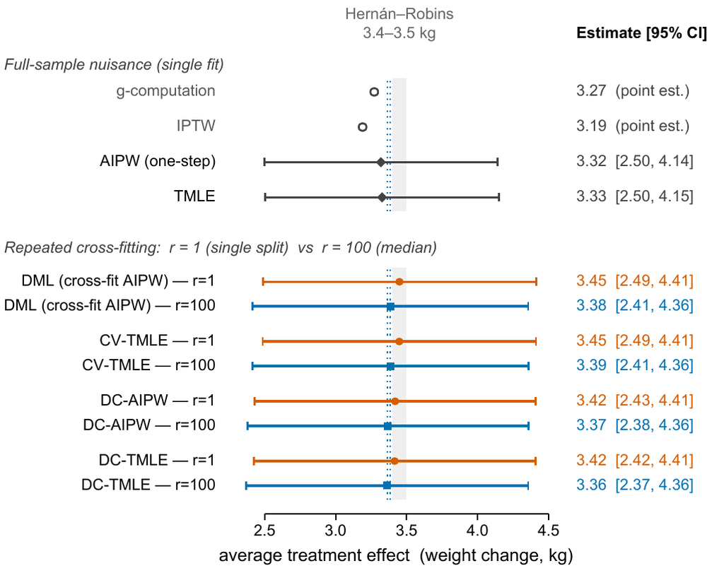

Figure 5

# Figure 6 — RHC estimator panel

`fig:rhc-panel`, drawn by [`R/figures/fig_forests.R`](https://github.com/ehsanx/dml-alternatives/blob/main/R/figures/fig_forests.R) from `data/real_application.csv` and `data/rhc_reps_table.csv`.

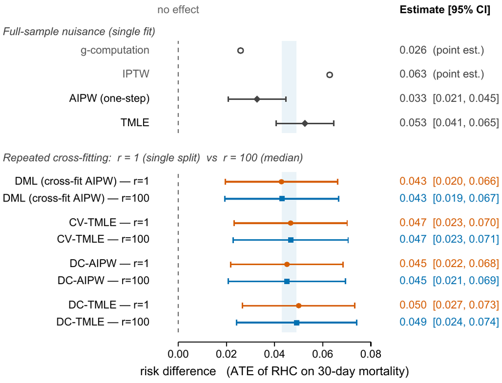

Figure 6

# Figure 7 — IHDP calibration

`fig:ihdp-grading`, drawn by [`R/figures/fig_ihdp.R`](https://github.com/ehsanx/dml-alternatives/blob/main/R/figures/fig_ihdp.R) from `data/grade_table.csv`: mean bias, RMSE, 95% CI coverage and mean 95% CI width over 50 realizations × 20 fold partitions, each scored as a single split. Bias and coverage carry Monte Carlo intervals with the 50 realizations as the units. Coverage is conditional on the benchmark’s fixed design; see below.

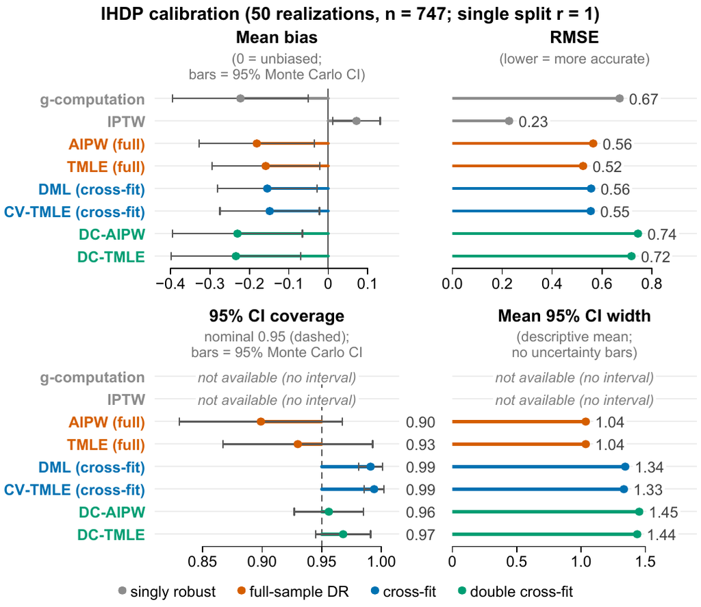

Figure 7

# Figure 8 — RHC repetition study

`fig:rhc-reps`, drawn by [`R/figures/fig_reps.R`](https://github.com/ehsanx/dml-alternatives/blob/main/R/figures/fig_reps.R) from `data/rhc_reps_table.csv`.

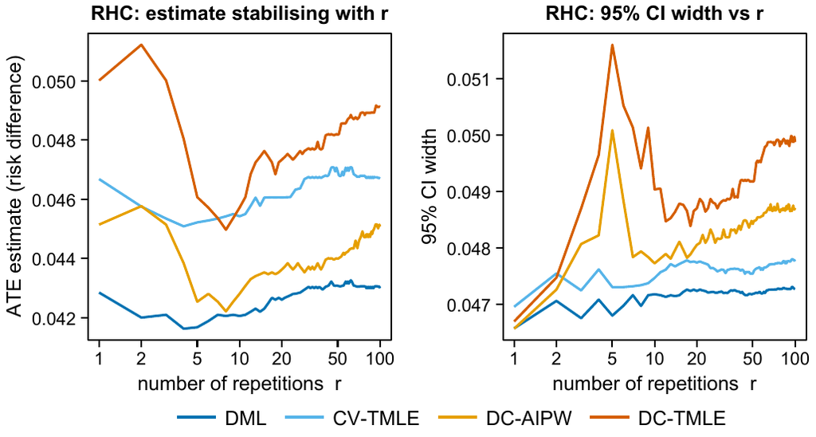

Figure 8

# Figure 9 — Overlap and the spread of the estimates

`fig:positivity`, drawn by [`python/paper_figures.py`](https://github.com/ehsanx/dml-alternatives/blob/main/python/paper_figures.py). The upper panels are densities of two diagnostic fits: the NHEFS scores of Figure 2 (`data/nhefs_overlap_data.csv`) and the seeded LaLonde/NSW–PSID diagnostic (`data/positivity_overlap.csv`, from part (1) of [`R/positivity_diagnostics.R`](https://github.com/ehsanx/dml-alternatives/blob/main/R/positivity_diagnostics.R)). The clipped peak of the LaLonde comparison group, about 154, is the Gaussian kernel density at R’s default bandwidth on a fine grid; R’s `density()` at its default 512 points gives about 123. The lower panels are the eight estimates (`data/nhefs_panel_table.csv`, medians over 100 splits; `data/results_all3.csv`, one split).

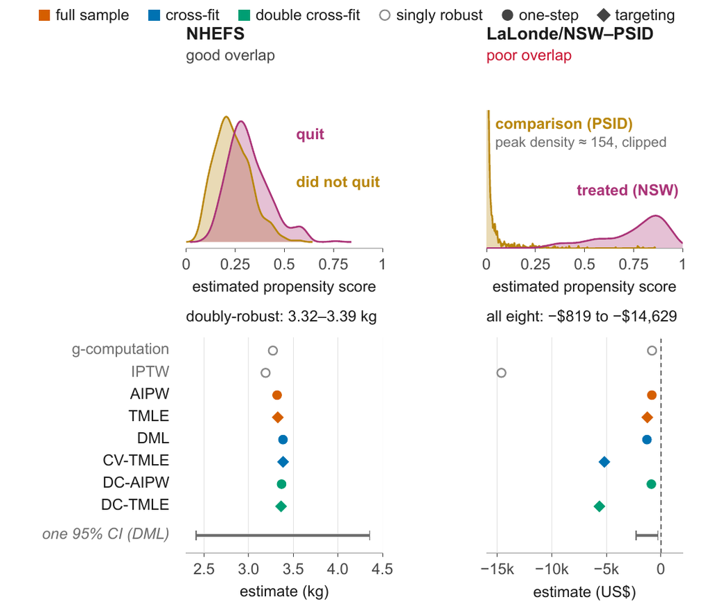

Figure 9

# Figure 10 — One estimand across implementations and seeds

`fig:software-seeds`, drawn by [`python/paper_figures.py`](https://github.com/ehsanx/dml-alternatives/blob/main/python/paper_figures.py) from `data/nhefs_software.csv` and `data/nhefs_matched_repeated.csv`.

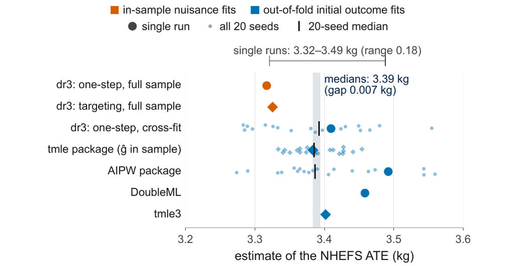

Figure 10

# Companion diagnostic: IHDP overlap

Not a manuscript figure. Step 5 of the manuscript cites it for the IHDP design’s overlap: the estimated-propensity densities of IHDP realization 1, from the seeded diagnostic `data/positivity_overlap.csv`.

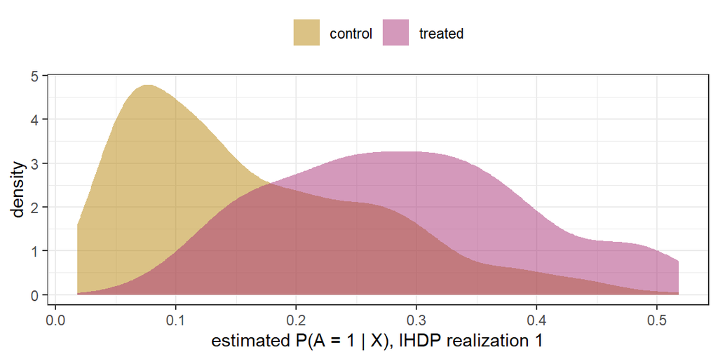

```r
library(ggplot2)
po <- rd("positivity_overlap.csv")
ih <- po[grepl("^IHDP", po$dataset), ]
ggplot(ih, aes(pi, fill = group)) +
  geom_density(alpha = 0.5, colour = NA) +
  scale_fill_manual(values = c(control = "#B8860B", treated = "#AA3377")) +
  labs(x = "estimated P(A = 1 | X), IHDP realization 1", y = "density", fill = NULL) +
  theme_bw(base_size = 11) + theme(legend.position = "top")
```

```r
cat(sprintf("IHDP realization 1: %d treated, %d comparison; scores %.3f to %.3f\n",
            sum(ih$group == "treated"), sum(ih$group == "control"), min(ih$pi), max(ih$pi)))
```

```
#> IHDP realization 1: 139 treated, 608 comparison; scores 0.018 to 0.518
```

# Sample sizes and design facts

`data/data_summary.csv`, written by [`R/data_summary.R`](https://github.com/ehsanx/dml-alternatives/blob/main/R/data_summary.R) from the raw data: the sample sizes and design facts the manuscript quotes (Tables 1 and 3, Steps 4 to 6), which the audit checks. For IHDP it confirms that all 50 realizations share one design.

```r
kab(rd("data_summary.csv"), row.names = FALSE, digits = 4)
```

| dataset | n | n_treated | outcome_mean | n_covariate_columns | design_fixed_all_50 |
| --- | --- | --- | --- | --- | --- |
| NHEFS (smoking cessation -> weight change) | 1566 | 403 | 2.6383 | 9 | NA |
| RHC (right heart cath -> dth30) | 5735 | 2184 | 0.3344 | 66 | NA |
| LaLonde/NSW (psid) | 2675 | 185 | 20502.3756 | 8 | NA |
| IHDP (realizations 1-50) | 747 | 139 | NA | 25 | TRUE |

# The numeric tables

[`R/make_tables.R`](https://github.com/ehsanx/dml-alternatives/blob/main/R/make_tables.R) writes every numeric table of the manuscript from the frozen CSVs, with the manuscript’s rounding and row order (`output/tables/`). Tables 2, 5, 7 and 12 are text only.

# Table 1 — NHEFS analytic sample

`tab:nhefs-sample`, from `data/data_summary.csv`.

| Group | n |
| --- | --- |
| Quit smoking (A=1) | 403 |
| Continued smoking (A=0) | 1163 |
| Total analytic sample | 1566 |

# Table 3 — NHEFS overlap diagnostics

`tab:nhefs-overlap`, from `data/data_summary.csv`, `data/nhefs_overlap_data.csv` and the engine’s truncation window.

| Diagnostic | Value |
| --- | --- |
| Sample size n | 1566 |
| Quit smoking (A=1) | 403 (25.7%) |
| Estimated propensity range | 0.044–0.759 |
| Truncation window | [0.025, 0.975] |
| Observations with capped propensity | 0 (0.0%) |

# Table 4 — What moves the NHEFS estimate

`tab:knobs`, from `data/nhefs_panel_table.csv` and `data/nhefs_software.csv`. The first three rows compare estimates within the engine (full-sample estimates are single fits; split-based estimates are medians over *r* = 100 splits); the last row compares single runs of the five implementations, which differ in several settings at once.

| Knob varied | Held fixed | Spread in estimate (kg) |
| --- | --- | --- |
| Estimator label (AIPW vs. TMLE) | library, folds, truncation | ≤ 0.01 |
| Cross-fitting scheme | label, library, truncation | 0.07 |
| Label and scheme together (six estimates) | library, truncation | 0.07 |
| Whole software implementation (single runs) | estimand only | 0.18 |

The ranges that the manuscript’s caption gives:

```r
p   <- rd("nhefs_panel_table.csv"); sw <- rd("nhefs_software.csv")
dr6 <- c(p$estimate[is.na(p$r) & p$estimator %in% c("AIPW (one-step)", "TMLE")],
         p$estimate[p$r %in% 100 & p$estimator %in% c("DML (cross-fit AIPW)", "CV-TMLE", "DC-AIPW", "DC-TMLE")])
swr <- function(pat) sw[grepl(pat, sw$source), ][1, ]
swv <- c(unlist(swr("^hand")[c("AIPW", "TMLE", "DML_crossfit")]), swr("^tmle \\(")$TMLE, swr("Zhong")$AIPW,
         swr("DoubleML")$DML_crossfit, swr("tmle3")$TMLE)
cat(sprintf("six doubly-robust estimates of the engine: %.2f to %.2f kg\nfive implementations, single runs: %.2f to %.2f kg\n",
            min(dr6), max(dr6), min(swv), max(swv)))
```

```
#> six doubly-robust estimates of the engine: 3.32 to 3.39 kg
#> five implementations, single runs: 3.32 to 3.49 kg
```

# Table 6 — NHEFS estimator panel

Singly-robust baselines and the doubly-robust repair (`tab:eif-repair`), from `data/nhefs_panel_table.csv` (the full-sample rows, `r=NA`).

| Estimator | Must be correct (for consistency) | Estimate (kg) | 95% CI |
| --- | --- | --- | --- |
| g-computation | outcome model Q | 3.27 | — |
| IPTW (stabilized) | propensity model g | 3.19 | — |
| AIPW (EIF one-step) | Q or g | 3.32 | (2.50, 4.14) |
| TMLE (EIF targeting) | Q or g | 3.33 | (2.50, 4.15) |

# Repeated splits: how much a single split moves the estimate

Behind the *r* = 100 rows of Figures 5 and 6: the single-split estimates of each split-based route across the 100 splits (`data/nhefs_reps_raw.csv`, `data/rhc_reps_raw.csv`), and the RHC running medians (`data/rhc_reps_table.csv`; Step 5).

```r
p  <- rd("nhefs_panel_table.csv")
nr <- rd("nhefs_reps_raw.csv"); rw <- rd("rhc_reps_raw.csv"); rt <- rd("rhc_reps_table.csv")
kab(data.frame(estimator = names(tapply(nr$estimate, nr$method, sd)),
               `NHEFS SD across splits (kg)` = round(tapply(nr$estimate, nr$method, sd), 3),
               check.names = FALSE, row.names = NULL))
```

| estimator | NHEFS SD across splits (kg) |
| --- | --- |
| CV-TMLE | 0.078 |
| DC-AIPW | 0.141 |
| DC-TMLE | 0.140 |
| DML (cross-fit AIPW) | 0.078 |

```r
full2 <- p$estimate[is.na(p$r) & p$estimator %in% c("AIPW (one-step)", "TMLE")]
spans <- tapply(nr$estimate, nr$rep, function(e) diff(range(c(e, full2))))
cat(sprintf("NHEFS six doubly-robust estimates on a single split: median span %.2f kg (IQR %.2f-%.2f)\n",
            median(spans), quantile(spans, .25), quantile(spans, .75)))
```

```
#> NHEFS six doubly-robust estimates on a single split: median span 0.15 kg (IQR 0.09-0.22)
```

```r
settle <- function(s, tol = 0.001) { ok <- abs(s$estimate - s$estimate[s$r == 100]) < tol
  for (k in seq_along(ok)) if (all(ok[k:length(ok)])) return(s$r[k]); NA }
kab(do.call(rbind, lapply(split(rt, rt$method), function(s) { s <- s[order(s$r), ]
  data.frame(estimator = s$method[1], `r = 1` = round(s$estimate[s$r == 1], 4),
             `r = 100` = round(s$estimate[s$r == 100], 4),
             `SD across splits` = round(sd(rw$estimate[rw$method == s$method[1]]), 4),
             `within 0.001 from r =` = settle(s),
             `largest distance from r = 100` = round(max(abs(s$estimate - s$estimate[s$r == 100])), 4),
             `CI width growth (%)` = round(100 * (s$ci_width[s$r == 100] / s$ci_width[s$r == 1] - 1), 1),
             check.names = FALSE) })), row.names = FALSE)
```

| estimator | r = 1 | r = 100 | SD across splits | within 0.001 from r = | largest distance from r = 100 | CI width growth (%) |
| --- | --- | --- | --- | --- | --- | --- |
| CV-TMLE (cross-fit) | 0.0467 | 0.0467 | 0.0021 | 12 | 0.0016 | 1.7 |
| DC-AIPW | 0.0451 | 0.0451 | 0.0030 | 54 | 0.0029 | 4.6 |
| DC-TMLE | 0.0500 | 0.0491 | 0.0037 | 41 | 0.0041 | 6.8 |
| DML (cross-fit) | 0.0428 | 0.0430 | 0.0017 | 7 | 0.0014 | 1.5 |

# RHC: in-sample vs out-of-fold residuals

`data/rhc_residual_diagnostic.csv`, from [`R/rhc_residual_diagnostic.R`](https://github.com/ehsanx/dml-alternatives/blob/main/R/rhc_residual_diagnostic.R) (Step 4): the original seed-1 RHC fits (`real_application.R`), full-sample and five-fold cross-fit, with the outcome model’s residual root-mean-square, the g-computation plug-in, and AIPW’s mean weighted correction. Figure 6 shows the same full-sample fit, but its split-based rows are the first of 100 splits and the median over them, so the seed-1 cross-fit AIPW here (0.044) differs from Figure 6’s DML (0.043). Without ground truth, the comparison does not establish which estimate is more accurate.

```r
kab(transform(rd("rhc_residual_diagnostic.csv"), resid_rms = round(resid_rms, 3), gcomp = round(gcomp, 4),
              correction = round(correction, 4), aipw = round(aipw, 4)), row.names = FALSE)
```

| scheme | resid_rms | gcomp | correction | aipw |
| --- | --- | --- | --- | --- |
| full sample (in-sample) | 0.304 | 0.0259 | 0.0068 | 0.0327 |
| cross-fit V=5 (out of fold) | 0.418 | 0.0297 | 0.0140 | 0.0437 |

# IHDP: design, paired contrasts, and the aggregated check

All 50 IHDP realizations share one fixed set of 747 covariate profiles and treatment assignments; each realization’s target is the sample average of its own simulated effect contrast. The coverage in Figure 7 is therefore conditional on this design, for a sample-average target. The realizations are generated independently given the design, so the realization is the Monte Carlo unit. [`R/ihdp_contrasts.R`](https://github.com/ehsanx/dml-alternatives/blob/main/R/ihdp_contrasts.R) recomputes the paired contrasts and the exploratory *r* = 20 check from `data/grade_raw.csv`; the chunk below runs it and confirms that it reproduces the committed CSVs.

```r
gr <- rd("grade_raw.csv"); tr <- tapply(gr$truth, gr$realization, unique)
cat(sprintf("%d realizations x %d fold seeds; sample-average targets %.2f to %.2f\n",
            length(tr), length(unique(gr$seed)), min(tr), max(tr)))
```

```
#> 50 realizations x 20 fold seeds; sample-average targets 3.16 to 12.65
```

```r
frozen_ct <- rd("ihdp_contrasts.csv"); frozen_pil <- rd("ihdp_aggregated_pilot.csv")
invisible(capture.output(source("../R/ihdp_contrasts.R")))
stopifnot(isTRUE(all.equal(rd("ihdp_contrasts.csv"), frozen_ct)),
          isTRUE(all.equal(rd("ihdp_aggregated_pilot.csv"), frozen_pil)))
kab(transform(frozen_ct, difference = round(difference, 4), paired_mcse = round(paired_mcse, 4), t = round(t, 2)))
```

| from | to | quantity | difference | paired_mcse | t |
| --- | --- | --- | --- | --- | --- |
| AIPW | AIPW = DML | coverage | 0.0920 | 0.0332 | 2.77 |
| AIPW | AIPW = DML | bias | 0.0266 | 0.0228 | 1.17 |
| AIPW | AIPW = DML | mse | -0.0093 | 0.0986 | -0.09 |
| AIPW | AIPW = DML | ci_width | 0.3069 | 0.0705 | 4.35 |
| TMLE | TMLE (CV-TMLE) | coverage | 0.0640 | 0.0323 | 1.98 |
| TMLE | TMLE (CV-TMLE) | bias | 0.0102 | 0.0207 | 0.49 |
| TMLE | TMLE (CV-TMLE) | mse | 0.0333 | 0.0786 | 0.42 |
| TMLE | TMLE (CV-TMLE) | ci_width | 0.2965 | 0.0694 | 4.27 |
| AIPW | AIPW (DC-AIPW) | coverage | 0.0570 | 0.0326 | 1.75 |
| AIPW | AIPW (DC-AIPW) | bias | -0.0491 | 0.0440 | -1.12 |
| AIPW | AIPW (DC-AIPW) | mse | 0.2351 | 0.1173 | 2.00 |
| AIPW | AIPW (DC-AIPW) | ci_width | 0.4161 | 0.0874 | 4.76 |
| TMLE | TMLE (DC-TMLE) | coverage | 0.0380 | 0.0311 | 1.22 |
| TMLE | TMLE (DC-TMLE) | bias | -0.0756 | 0.0462 | -1.64 |
| TMLE | TMLE (DC-TMLE) | mse | 0.2412 | 0.1131 | 2.13 |
| TMLE | TMLE (DC-TMLE) | ci_width | 0.4004 | 0.0849 | 4.72 |
| AIPW = DML | AIPW (DC-AIPW) | coverage | -0.0350 | 0.0120 | -2.92 |
| AIPW = DML | AIPW (DC-AIPW) | bias | -0.0757 | 0.0448 | -1.69 |
| AIPW = DML | AIPW (DC-AIPW) | mse | 0.2444 | 0.1327 | 1.84 |
| AIPW = DML | AIPW (DC-AIPW) | ci_width | 0.1092 | 0.0280 | 3.90 |
| TMLE (CV-TMLE) | TMLE (DC-TMLE) | coverage | -0.0260 | 0.0102 | -2.54 |
| TMLE (CV-TMLE) | TMLE (DC-TMLE) | bias | -0.0857 | 0.0468 | -1.83 |
| TMLE (CV-TMLE) | TMLE (DC-TMLE) | mse | 0.2079 | 0.1273 | 1.63 |
| TMLE (CV-TMLE) | TMLE (DC-TMLE) | ci_width | 0.1039 | 0.0276 | 3.77 |

```r
kab(frozen_pil)
```

| estimator | realizations | included | inclusion |
| --- | --- | --- | --- |
| AIPW = DML | 50 | 50 | 1 |
| TMLE (CV-TMLE) | 50 | 50 | 1 |
| AIPW (DC-AIPW) | 50 | 50 | 1 |
| TMLE (DC-TMLE) | 50 | 50 | 1 |

```r
p10 <- function(e) { s <- gr[gr$estimator == e & gr$realization <= 10, ]; tapply(as.numeric(s$covers), s$realization, mean) }
d10 <- p10("AIPW = DML") - p10("AIPW")
cat(sprintf("Small-pilot example (Step 5), realizations 1-10 alone: AIPW->DML coverage gap %.3f (paired MCSE %.3f)\n",
            mean(d10), sd(d10) / sqrt(length(d10))))
```

```
#> Small-pilot example (Step 5), realizations 1-10 alone: AIPW->DML coverage gap 0.275 (paired MCSE 0.123)
```

```r
cat(sprintf("50/50: 95%% Clopper-Pearson interval %.2f-1.00\n", qbeta(0.025, 50, 1)))
```

```
#> 50/50: 95% Clopper-Pearson interval 0.93-1.00
```

# Table 8 — LaLonde/NSW-PSID: every route under poor overlap

`data/results_all3.csv` (`tab:positivity-full`): each estimator on the full, untrimmed sample; split-based rows use one random split. The $1,794 experimental estimate concerns a different population and is not a benchmark for these estimates, so no bias or coverage is shown.

| Estimator | Nuisance fitting | Estimate (US$) |
| --- | --- | --- |
| g-computation | full-sample | -819 |
| IPTW | full-sample | -14,629 |
| AIPW | full-sample | -833 |
| TMLE | full-sample | -1,254 |
| AIPW = DML | cross-fit | -1,284 |
| CV-TMLE | cross-fit | -5,186 |
| DC-AIPW | double-cross-fit | -881 |
| DC-TMLE | double-cross-fit | -5,644 |

Seed sensitivity (`data/lalonde_seed_sweep.csv`, 8 seeds): the values move, but every doubly-robust estimate stays negative, and the out-of-fold TMLE estimates stay far below the full-sample ones.

```r
sw8 <- rd("lalonde_seed_sweep.csv")
kab(do.call(rbind, lapply(split(sw8, sw8$estimator), function(x) data.frame(
  estimator = x$estimator[1], nuisance = x$nuisance[1], median = round(median(x$estimate)),
  min = round(min(x$estimate)), max = round(max(x$estimate))))), row.names = FALSE)
```

| estimator | nuisance | median | min | max |
| --- | --- | --- | --- | --- |
| AIPW | full | -822 | -1260 | -683 |
| AIPW (DC-AIPW) | double-cross-fit | -666 | -1269 | -177 |
| AIPW = DML | cross-fit | -1291 | -1611 | -964 |
| g-computation | full | -804 | -1255 | -655 |
| IPTW | full | -14460 | -14629 | -14340 |
| TMLE | full | -1495 | -2093 | -1254 |
| TMLE (CV-TMLE) | cross-fit | -5077 | -5384 | -3641 |
| TMLE (DC-TMLE) | double-cross-fit | -4830 | -5644 | -4125 |

# Table 9 — LaLonde/NSW-PSID trimming

`data/positivity_trimming_lalonde.csv` (`tab:positivity`): restricting to the estimated common-support region discards most of the sample and changes the population, and with it the estimand; the trimmed intervals are wide and include zero.

| Trimming rule | n kept | % kept | Estimate (US$) \| 95% CI (US$) |  |
| --- | --- | --- | --- | --- |
| None (all data) | 2,675 | 100 | -1,284 | (-2,278, -291) |
| ĝ ∈ [0.05, 0.95] | 423 | 16 | +484 | (-1,229, 2,196) |
| ĝ ∈ [0.10, 0.90] | 300 | 11 | -27 | (-2,214, 2,161) |

# Table 10 — Reporting checklist: numeric entries and settings

`tab:checklist` is a text table. Its numeric entries, and the settings it names, come from the frozen CSVs and from the engine itself (`R/estimators.R`: the Super Learner library, the fold counts and the truncation window).

| Item | Quantity | Value |
| --- | --- | --- |
| Estimand | n | 1566 |
| Estimand | quitters | 403 |
| Super Learner library | library (default_SL) | SL.mean, SL.glm, SL.glmnet, SL.ranger, SL.earth |
| Cross-fitting | single cross-fit folds V | 5 |
| Cross-fitting | double cross-fit folds V | 3 |
| Cross-fitting | repetitions r | 100 |
| Cross-fitting | SD of single-split estimates, cross-fit (kg) | 0.08 |
| Cross-fitting | SD of single-split estimates, double cross-fit (kg) | 0.14 |
| Propensity truncation | bounds | [0.025, 0.975] |
| Propensity truncation | bound on the clever covariate \|H\| | 40 |
| Trimmed fraction and sensitivity | observations the bounds bind on, over the audited analysis fits | 0 |
| Trimmed fraction and sensitivity | span of the six doubly-robust estimates at r = 100 (kg) | 0.07 |
| Trimmed fraction and sensitivity | share of the sample discarded by trimming (Step 6) | 84–89% |

# Table 11 — Software comparison on NHEFS

`data/nhefs_software.csv` (`tab:software`), in the manuscript’s layout: one run of each implementation on the same estimand. The entries differ in several settings at once (fitting scheme, library, combination rule), and each carries single-split noise, so the table alone cannot say which setting moves the number.

| Implementation | Combination rule | Nuisance-fitting scheme | Estimate (kg) |
| --- | --- | --- | --- |
| Hand-coded (dr3) | One-step | Full sample | 3.32 |
| Hand-coded (dr3) | Targeting | Full sample | 3.33 |
| Hand-coded (dr3) | One-step | Five-fold cross-fit | 3.41 |
| tmle | Targeting | Out-of-fold initial Q̂; full-sample ĝ | 3.38 |
| AIPW | One-step | Five-fold cross-fit | 3.49 |
| DoubleML | One-step | Five-fold cross-fit | 3.46 |
| tmle3 | Targeting | Cross-fit initial fits (CV-TMLE) | 3.40 |

# Software reconciliation over 20 seeds

`data/nhefs_matched_repeated.csv`: the three implementations built on the paper’s Super Learner library (the hand-coded engine, `tmle`, and `AIPW`), each re-run with 20 seeds and an explicit 0.025 propensity bound. The single runs scatter (SD across seeds about 0.08 kg for a single five-fold cross-fit), but the medians agree to within 0.01 kg. The combined differences yield similar medians here; the effects of individual implementation choices are not isolated (Step 7).

```r
mr <- rd("nhefs_matched_repeated.csv")
cols <- c("hand_DML","AIPW_pkg","tmle_pkg")
kab(data.frame(
  implementation = c("hand-coded engine (DML)", "AIPW package", "tmle package"),
  `median (kg)`  = round(sapply(mr[cols], median, na.rm = TRUE), 2),
  `SD across seeds` = round(sapply(mr[cols], sd, na.rm = TRUE), 3),
  check.names = FALSE, row.names = NULL))
```

| implementation | median (kg) | SD across seeds |
| --- | --- | --- |
| hand-coded engine (DML) | 3.39 | 0.075 |
| AIPW package | 3.39 | 0.082 |
| tmle package | 3.39 | 0.036 |

# Truncation audit

`data/nhefs_truncation_audit.csv`: pre-truncation propensity ranges of the five-learner NHEFS analysis fits, and the number of units the [0.025, 0.975] bound clips (Step 1).

```r
kab(rd("nhefs_truncation_audit.csv"), row.names = FALSE)
```

| fit | fits | raw_min | raw_max | max_clipped | total_clipped |
| --- | --- | --- | --- | --- | --- |
| full sample (seed 1) | 1 | 0.0763 | 0.7215 | 0 | 0 |
| cross-fit V=5 (seed 1) | 1 | 0.0804 | 0.6943 | 0 | 0 |
| double cross-fit (seed 1 and reps 1-100) | 101 | 0.0323 | 0.8380 | 0 | 0 |

# Supplementary: three-benchmark comparison (not in the manuscript)

`data/results_all3.csv`: one run of the full panel on IHDP realization 1, LaLonde/NSW-PSID, and Twins. Twins is not used in the manuscript and its double-cross-fit rows were not rerun after the correction, so the table has no double-cross-fit rows for Twins. For LaLonde the `truth` column holds the $1,794 experimental estimate, which concerns a different population; bias and coverage are shown only for IHDP and Twins.

```r
r3 <- rd("results_all3.csv")
show <- r3[, c("dataset","estimator","nuisance","estimate","ci_lo","ci_hi","bias","covers")]
show$bias[grepl("psid", show$dataset, ignore.case = TRUE)] <- NA
show$covers[grepl("psid", show$dataset, ignore.case = TRUE)] <- NA
kab(transform(show, estimate = round(estimate, 3), ci_lo = round(ci_lo, 3),
              ci_hi = round(ci_hi, 3), bias = round(bias, 3)), row.names = FALSE)
```

| dataset | estimator | nuisance | estimate | ci_lo | ci_hi | bias | covers |
| --- | --- | --- | --- | --- | --- | --- | --- |
| IHDP (realization 1) | g-computation | full | 3.853 | NA | NA | -0.163 | NA |
| IHDP (realization 1) | IPTW | full | 4.029 | NA | NA | 0.013 | NA |
| IHDP (realization 1) | AIPW | full | 3.932 | 3.766 | 4.098 | -0.084 | TRUE |
| IHDP (realization 1) | TMLE | full | 3.963 | 3.798 | 4.127 | -0.053 | TRUE |
| IHDP (realization 1) | AIPW = DML | cross-fit | 3.979 | 3.757 | 4.202 | -0.037 | TRUE |
| IHDP (realization 1) | TMLE (CV-TMLE) | cross-fit | 3.979 | 3.757 | 4.200 | -0.037 | TRUE |
| IHDP (realization 1) | AIPW (DC-AIPW) | double-cross-fit | 3.904 | 3.686 | 4.123 | -0.112 | TRUE |
| IHDP (realization 1) | TMLE (DC-TMLE) | double-cross-fit | 3.922 | 3.706 | 4.137 | -0.095 | TRUE |
| LaLonde/NSW (psid) | g-computation | full | -819.043 | NA | NA | NA | NA |
| LaLonde/NSW (psid) | IPTW | full | -14629.014 | NA | NA | NA | NA |
| LaLonde/NSW (psid) | AIPW | full | -833.414 | -1171.107 | -495.720 | NA | NA |
| LaLonde/NSW (psid) | TMLE | full | -1254.266 | -1593.509 | -915.023 | NA | NA |
| LaLonde/NSW (psid) | AIPW = DML | cross-fit | -1284.464 | -2277.938 | -290.990 | NA | NA |
| LaLonde/NSW (psid) | TMLE (CV-TMLE) | cross-fit | -5186.129 | -6141.756 | -4230.501 | NA | NA |
| LaLonde/NSW (psid) | AIPW (DC-AIPW) | double-cross-fit | -880.638 | -1930.144 | 168.868 | NA | NA |
| LaLonde/NSW (psid) | TMLE (DC-TMLE) | double-cross-fit | -5643.738 | -6584.301 | -4703.175 | NA | NA |
| Twins (simulated confounding) | g-computation | full | -0.006 | NA | NA | 0.009 | NA |
| Twins (simulated confounding) | IPTW | full | -0.022 | NA | NA | -0.007 | NA |
| Twins (simulated confounding) | AIPW | full | -0.021 | -0.038 | -0.003 | -0.006 | TRUE |
| Twins (simulated confounding) | TMLE | full | -0.023 | -0.040 | -0.005 | -0.008 | TRUE |
| Twins (simulated confounding) | AIPW = DML | cross-fit | -0.035 | -0.065 | -0.005 | -0.020 | TRUE |
| Twins (simulated confounding) | TMLE (CV-TMLE) | cross-fit | -0.035 | -0.062 | -0.008 | -0.020 | TRUE |

# Numeric audit — every reported number vs. its CSV

The deterministic audit [`R/verify_numbers.R`](https://github.com/ehsanx/dml-alternatives/blob/main/R/verify_numbers.R) re-derives the data-bearing numbers in the manuscript from these same CSVs and diffs each against the printed value. A table with `0 FAIL` means the paper and the committed results agree.

```r
invisible(capture.output(source("../R/verify_numbers.R")))
cat(sprintf("%d checks: %d PASS, %d FAIL\n",
            nrow(res), sum(res$status == "PASS"), sum(res$status == "FAIL")))
```

```
#> 270 checks: 270 PASS, 0 FAIL
```

```r
kab(res)
```

| check | printed | computed | status |
| --- | --- | --- | --- |
| NHEFS g-computation full (Table 6 = 3.27) | 3.2700 | 3.2700 | PASS |
| NHEFS IPTW full (Table 6 = 3.19) | 3.1900 | 3.1900 | PASS |
| NHEFS AIPW full (Table 6 = 3.32) | 3.3200 | 3.3200 | PASS |
| NHEFS TMLE full (Table 6 = 3.33) | 3.3300 | 3.3300 | PASS |
| NHEFS AIPW full CI lower (2.50) | 2.5000 | 2.5000 | PASS |
| NHEFS AIPW full CI upper (4.14) | 4.1400 | 4.1400 | PASS |
| NHEFS TMLE full CI lower (2.50) | 2.5000 | 2.5000 | PASS |
| NHEFS TMLE full CI upper (4.15) | 4.1500 | 4.1500 | PASS |
| NHEFS DML r=100 (Fig 5 = 3.38) | 3.3800 | 3.3800 | PASS |
| NHEFS CV-TMLE r=100 (Fig 5 = 3.39) | 3.3900 | 3.3900 | PASS |
| NHEFS DC-AIPW r=100 (Fig 5 = 3.37) | 3.3700 | 3.3700 | PASS |
| NHEFS DC-TMLE r=100 (Fig 5 = 3.36) | 3.3600 | 3.3600 | PASS |
| NHEFS DML r=1 (Fig 5 = 3.45) | 3.4500 | 3.4500 | PASS |
| NHEFS CV-TMLE r=1 (Fig 5 = 3.45) | 3.4500 | 3.4500 | PASS |
| NHEFS DC-AIPW r=1 (Fig 5 = 3.42) | 3.4200 | 3.4200 | PASS |
| NHEFS DC-TMLE r=1 (Fig 5 = 3.42) | 3.4200 | 3.4200 | PASS |
| NHEFS DML r=100 CI lower (2.41) | 2.4100 | 2.4100 | PASS |
| NHEFS DML r=100 CI upper (4.36) | 4.3600 | 4.3600 | PASS |
| NHEFS six-DR span r=100 min (3.32) | 3.3200 | 3.3200 | PASS |
| NHEFS six-DR span r=100 max (3.39) | 3.3900 | 3.3900 | PASS |
| NHEFS six-DR spread r=100 (0.07) | 0.0700 | 0.0700 | PASS |
| NHEFS six-DR spread incl. r=1 rows (0.13) | 0.1300 | 0.1300 | PASS |
| NHEFS split-based r=100 min (Step 7 = 3.36) | 3.3600 | 3.3600 | PASS |
| NHEFS split-based r=100 max (Step 7 = 3.39) | 3.3900 | 3.3900 | PASS |
| NHEFS label swap, largest (Table 4 <= 0.01) | 0.0100 | 0.0100 | PASS |
| NHEFS fold scheme, largest move (Table 4 = 0.07) | 0.0700 | 0.0700 | PASS |
| NHEFS r=1 -> r=100 shift, smallest (0.05) | 0.0500 | 0.0500 | PASS |
| NHEFS r=1 -> r=100 shift, largest (0.06) | 0.0600 | 0.0600 | PASS |
| NHEFS CI width, narrowest (1.6) | 1.6000 | 1.6000 | PASS |
| NHEFS CI width, widest (2.0) | 2.0000 | 2.0000 | PASS |

[output cut: 240 more lines]

# Data sources and computing environments

The manuscript’s Data and Code availability statements refer to this section and to the repository [`README`](https://github.com/ehsanx/dml-alternatives/blob/main/README.md#raw-data). Nothing on this page reads the raw data: they are needed only to refit the analyses, and none of them is redistributed with the manuscript or here. The source’s terms of use apply to each dataset.

| Dataset | Source | Files, under `data/` |
| --- | --- | --- |
| NHEFS (Hernán and Robins, 2020) | the `nhefs` data of the `causaldata` R package (version 0.1.4 on CRAN) | none |
| Right-heart catheterization (Connors et al., 1996) | Vanderbilt’s CSV export of the RHC dataset, `rhc.csv`, from the [Right Heart Catheterization Dataset page](https://hbiostat.org/data/repo/rhc) of hbiostat.org (https://hbiostat.org/data/repo/rhc.csv).… | `rhc/rhc.csv` |
| LaLonde/NSW–PSID (LaLonde, 1986; Dehejia and Wahba, 1999) | the Dehejia–Wahba experimental sample, `nsw_dw.dta`, and the PSID comparison sample, `psid_controls.dta`, from https://users.nber.org/~rdehejia/nswdata2.html | `lalonde_nsw/nsw_dw.dta`, `lalonde_nsw/psid_controls.dta` |
| IHDP semi-synthetic benchmark (Hill, 2011) | realizations 1–50, `ihdp_npci_1.csv` to `ihdp_npci_50.csv`, from https://github.com/claudiashi57/dragonnet, folder `dat/ihdp/csv/` at commit `2e51b24788` | `ihdp/ihdp_npci_1.csv` to `ihdp/ihdp_npci_50.csv` |
| Twins (supplementary; Louizos et al., 2017) | `data/Twin_data.csv.gz` from https://github.com/jsyoon0823/GANITE at commit `e2997317d5` | `twins/Twin_data.csv.gz` |

[`R/check_data.R`](https://github.com/ehsanx/dml-alternatives/blob/main/R/check_data.R) compares the files with their MD5 checksums, rows and columns, [`data/checksums.csv`](https://github.com/ehsanx/dml-alternatives/blob/main/data/checksums.csv):

```r
kab(read.csv(file.path("..", "data", "checksums.csv")), row.names = FALSE)
```

| dataset | file | md5 | rows | columns |
| --- | --- | --- | --- | --- |
| LaLonde/NSW | lalonde_nsw/nsw_dw.dta | e3367ddd449e25cb4c54c04263978800 | 445 | 11 |
| LaLonde/NSW | lalonde_nsw/psid_controls.dta | 1ae3ab3bc7c40048f41b0953a5e634f8 | 2490 | 11 |
| RHC | rhc/rhc.csv | a765300feca874a1bed613b2a7df374b | 5735 | 63 |
| Twins | twins/Twin_data.csv.gz | f8fab2d91b4fff7117f8ae19578c74fa | 11400 | 32 |
| IHDP | ihdp/ihdp_npci_1.csv | 251f0ca7ee260a4f528689aae22a436d | 747 | 30 |
| IHDP | ihdp/ihdp_npci_2.csv | 39b6052f1ddbed2d4517dfc4ea6ed28d | 747 | 30 |
| IHDP | ihdp/ihdp_npci_3.csv | a6e865001dd5c682a76f89a14aaaf56c | 747 | 30 |
| IHDP | ihdp/ihdp_npci_4.csv | 9254988038408c6be2307d82dd4ec89f | 747 | 30 |
| IHDP | ihdp/ihdp_npci_5.csv | 5f0a347374dc70717c66598cd85b5b8f | 747 | 30 |
| IHDP | ihdp/ihdp_npci_6.csv | 9ef09f4e6a530cb4578acafcf6bd2c00 | 747 | 30 |
| IHDP | ihdp/ihdp_npci_7.csv | 092c4dd1a75aa18f3ce7d9ed8d1ec0f8 | 747 | 30 |
| IHDP | ihdp/ihdp_npci_8.csv | 3e7187abf92c43374e37f5c4dec25acf | 747 | 30 |
| IHDP | ihdp/ihdp_npci_9.csv | 3ff1f6ec3d1a862faa802e46d59a0046 | 747 | 30 |
| IHDP | ihdp/ihdp_npci_10.csv | 35161c5f75dac289828dc8a94fb86f5e | 747 | 30 |
| IHDP | ihdp/ihdp_npci_11.csv | e268c04db112f74f8a86f7ffc986502e | 747 | 30 |
| IHDP | ihdp/ihdp_npci_12.csv | 367065a55e215b9b6bff01f74bb66d37 | 747 | 30 |
| IHDP | ihdp/ihdp_npci_13.csv | 935e0255a731342128e53322ec6ddc59 | 747 | 30 |
| IHDP | ihdp/ihdp_npci_14.csv | 132cf8efe5dbdfa34ac7499acc74adac | 747 | 30 |
| IHDP | ihdp/ihdp_npci_15.csv | 9849614230f730d1f264a2970a6ad6d4 | 747 | 30 |
| IHDP | ihdp/ihdp_npci_16.csv | de109803186f3e1f604d87bd2ab0f505 | 747 | 30 |
| IHDP | ihdp/ihdp_npci_17.csv | 5e23bcbab69e949bd216fab343a72af6 | 747 | 30 |
| IHDP | ihdp/ihdp_npci_18.csv | 4d442929ca4c4ac344aa86bbd09135c8 | 747 | 30 |
| IHDP | ihdp/ihdp_npci_19.csv | d127ccbe8dbae1a0f45209e7a78448ca | 747 | 30 |
| IHDP | ihdp/ihdp_npci_20.csv | 8c811fe68ba97efe14b4d719b711dadc | 747 | 30 |
| IHDP | ihdp/ihdp_npci_21.csv | 0c56b6a0fe95ab8bfbee73afad46bfff | 747 | 30 |
| IHDP | ihdp/ihdp_npci_22.csv | 742639231e576d109071e7267e846504 | 747 | 30 |
| IHDP | ihdp/ihdp_npci_23.csv | e335b02523fc8293a98dd76d38ad35cc | 747 | 30 |
| IHDP | ihdp/ihdp_npci_24.csv | 6af063ec1172080009fa95cc1361b3ec | 747 | 30 |
| IHDP | ihdp/ihdp_npci_25.csv | 8ef043cf34c1665b5f559b493aecb82d | 747 | 30 |
| IHDP | ihdp/ihdp_npci_26.csv | 5843570499f09ecdbe6423d765dfda6f | 747 | 30 |
| IHDP | ihdp/ihdp_npci_27.csv | a09c75ba58f7b1bc8e530dfdc269cc7b | 747 | 30 |
| IHDP | ihdp/ihdp_npci_28.csv | fabf13a5bac5be59730dfb53e85578d8 | 747 | 30 |
| IHDP | ihdp/ihdp_npci_29.csv | 1883624d55a4be5d8849412f3a5964a0 | 747 | 30 |
| IHDP | ihdp/ihdp_npci_30.csv | c72f6fe2bdfcea6527200e2e42da4eae | 747 | 30 |
| IHDP | ihdp/ihdp_npci_31.csv | 8942c6daf13158a0968662d51dcbd4d7 | 747 | 30 |
| IHDP | ihdp/ihdp_npci_32.csv | 6ed0511b3ee078c9e22877587eda6381 | 747 | 30 |
| IHDP | ihdp/ihdp_npci_33.csv | b61b572ce287e830c61b04de9ca68e09 | 747 | 30 |
| IHDP | ihdp/ihdp_npci_34.csv | 23de38c3a0fde8f2a01f8848852e31d0 | 747 | 30 |
| IHDP | ihdp/ihdp_npci_35.csv | 0b2e858ed64a7e0fb36ded2fb16fae75 | 747 | 30 |
| IHDP | ihdp/ihdp_npci_36.csv | b3fd77750ec94d3fcfc10df8c966b1e6 | 747 | 30 |
| IHDP | ihdp/ihdp_npci_37.csv | 8d7646ea5151a2def92b584247b855f9 | 747 | 30 |
| IHDP | ihdp/ihdp_npci_38.csv | b01889d43b13831ea41c78e7817708d8 | 747 | 30 |
| IHDP | ihdp/ihdp_npci_39.csv | 56352b9415d2516012b8ad1ce0ff0b65 | 747 | 30 |
| IHDP | ihdp/ihdp_npci_40.csv | ea23ae50458f61a7fb9f06018ed6c2d4 | 747 | 30 |
| IHDP | ihdp/ihdp_npci_41.csv | 2174a57381be4b6add8968aad2b5fa0f | 747 | 30 |
| IHDP | ihdp/ihdp_npci_42.csv | 165c91203c434fe6a52b0e62e0609646 | 747 | 30 |
| IHDP | ihdp/ihdp_npci_43.csv | ed8136f29fe91f2517b5bc753c648406 | 747 | 30 |
| IHDP | ihdp/ihdp_npci_44.csv | fbaefebd2c7b5cea60e4292f7567dfff | 747 | 30 |
| IHDP | ihdp/ihdp_npci_45.csv | 3cbd846b0f807e2c3d99e8496f155952 | 747 | 30 |
| IHDP | ihdp/ihdp_npci_46.csv | 548139f9e1ea91d4eedcedd81cbb8781 | 747 | 30 |
| IHDP | ihdp/ihdp_npci_47.csv | 153335327a96cec72dc371bf10b331db | 747 | 30 |
| IHDP | ihdp/ihdp_npci_48.csv | e20036f4f17053f16566f81311d15546 | 747 | 30 |
| IHDP | ihdp/ihdp_npci_49.csv | 86f986d517d8b88b316869893cd9899c | 747 | 30 |
| IHDP | ihdp/ihdp_npci_50.csv | b64306b81071e49c928ea25717f9e730 | 747 | 30 |

| Environment | Used for | Recorded in |
| --- | --- | --- |
| Windows workstation, R 4.5.1 | The original analyses other than the repeated-split and grading jobs; the corrected double-cross-fit run; the figures, this page and the audit | [`renv.lock`](https://github.com/ehsanx/dml-alternatives/blob/main/renv.lock); [`sessionInfo.txt`](https://github.com/ehsanx/dml-alternatives/blob/main/sessionInfo.txt), whose R, platform and package … |
| Linux cluster, R 4.4.0 | The repeated-split and grading jobs (`R/nhefs_panel_reps.R`, `R/reps_rhc.R`, `R/grade_ihdp.R`), apart from their double-cross-fit rows | not recorded: the package versions of the cluster’s R library were not saved |
| Python 3.10.6 | Figures 3, 4, 9 and 10 and the figure comparison | [`requirements.txt`](https://github.com/ehsanx/dml-alternatives/blob/main/requirements.txt) |

```r
si <- readLines(file.path("..", "sessionInfo.txt"))
pk <- grep("^== analysis package versions", si)
cat(c(grep("^R version|^Platform|^Running under", si, value = TRUE), "", si[pk:length(si)]), sep = "\n")
```

[output not shown]

**Fits that were not seeded.** The NHEFS propensity-overlap diagnostic (`data/nhefs_overlap_data.csv`) and the full-sample fits of the IHDP grading (`data/grade_raw.csv`) were not seeded per unit, so a rerun gives slightly different values; for these fits, the archived files are the reference. Rerunning `R/grade_ihdp.R` for realization 1 and fold seed 1 on the workstation reproduced both double-cross-fit rows exactly and the other six rows to within 0.04.

**Refitting.** Refitting a stochastic analysis from the raw data need not reproduce the archived values exactly. Super Learner fits depend on learner-package versions and on the computing platform, and the rows from the cluster jobs cannot be guaranteed to regenerate exactly, because that environment’s package versions are unknown.